# pubg_kaggle

This notebook created for Pubg kaggle competition. I used two algorithms Random forest and XGBoost in this notebook. The score I got on the public leaderboard is 0.055 and 0.071 from the two submission file respectively, which ranked me 245 in the leaderboard. But the best result I have got is from NN which is 0.0247 ranked me 147 overall out of 840. We could get a better score by increasing the RF tree and more feature Engineering because it is feature Engineering which makes the difference always.

```python
# Importing Libraries
import numpy as np
import pandas as pd
import matplotlib.pyplot as plt
import seaborn as sns
import warnings
warnings.filterwarnings("ignore")
```

```python
train = pd.read_csv('train_V2.csv')
```

## Let's understand the Dataframe first...

```python
print('Shape of training set: ', train.shape)
train.dtypes.value_counts()
```

```
Shape of training set:  (4446966, 29)
```

```
int64      19
float64     6
object      4
dtype: int64
```

```python
#train.info()
for col in train:
    print ("Column",col ," has " ,train[col].nunique() ," unique values" , train[col].unique())
```

```
Column Id  has  4446966  unique values ['7f96b2f878858a' 'eef90569b9d03c' '1eaf90ac73de72' ... 'e1948b1295c88a'
 'cc032cdd73b7ac' '0d8e7ed728b6fd']
Column groupId  has  2026745  unique values ['4d4b580de459be' '684d5656442f9e' '6a4a42c3245a74' ... 'ac3f1b4a56e5ad'
 '408cdb5c46b2ac' '8c74f72fedf5ff']
Column matchId  has  47965  unique values ['a10357fd1a4a91' 'aeb375fc57110c' '110163d8bb94ae' ... '21beed46753ed9'
 '224a123c53e008' 'fcad6c3fdd847a']
Column assists  has  20  unique values [ 0  1  3  2  4  6  5  8  9  7 13 11 12 21 10 20 14 17 22 15]
Column boosts  has  27  unique values [ 0  1  2  3  4  6  5  9  7  8 11 10 13 14 12 21 15 20 16 17 33 19 18 24
 28 23 22]
Column damageDealt  has  29916  unique values [ 0.     91.47   68.     ...  6.828   0.8276  0.8705]
Column DBNOs  has  39  unique values [ 0  1  6  4  3  2  5 10  8  7  9 13 21 12 11 19 32 18 24 22 20 14 15 26
 17 16 25 27 23 33 38 30 29 31 39 35 40 28 53]
Column headshotKills  has  34  unique values [ 0  1  2  3  6  4  5  8  9  7 17 10 14 12 40 11 13 15 16 18 27 19 21 23
 42 31 20 46 39 34 26 64 41 35]
Column heals  has  63  unique values [ 0  5  2 14 12  1  8  3  4  6  9 13  7 24 10 15 25 11 18 17 20 16 29 23
 19 21 22 27 28 32 47 26 31 30 43 33 37 34 38 52 35 42 48 40 41 44 39 45
 36 61 46 57 63 50 55 49 59 54 51 56 73 80 62]
Column killPlace  has  101  unique values [ 60  57  47  75  45  44  96  48  64  74  37   5  25  72  13  79  18  15
   2   3  11  78   7   6  87  62  80  61  34  24  82  73  31  86  46  12
  27  77  19  10  63  67  36   4  29  16   8  41  21  38  55  49  91  54
  40  69  92  23  71  30  20  81  56  84  66  52  85  94  50  83  58  68
  65  28  26  51  35  90  89  42  59  53  33   9  88  43  70  17  76   1
  95  99  22  39  32  93  14  97  98 100 101]
Column killPoints  has  1707  unique values [1241    0 1262 ... 2043 2120  392]
Column kills  has  58  unique values [ 0  1  4  2  9  3  5  6  8  7 14 13 15 12 21 11 10 17 20 24 18 16 22 19
 23 35 31 27 25 48 42 30 26 65 39 33 28 29 34 57 55 56 36 38 37 44 66 41
 50 53 43 32 40 47 45 46 49 72]
Column killStreaks  has  18  unique values [ 0  1  2  4  3  5  6  7 10 14  8  9 11 12 13 16 18 20]
Column longestKill  has  28284  unique values [ 0.     58.53   18.44   ...  0.5843  0.6309  0.7761]
Column matchDuration  has  1267  unique values [1306 1777 1318 ...  657  990    9]
Column matchType  has  16  unique values ['squad-fpp' 'duo' 'solo-fpp' 'squad' 'duo-fpp' 'solo' 'normal-squad-fpp'
 'crashfpp' 'flaretpp' 'normal-solo-fpp' 'flarefpp' 'normal-duo-fpp'
 'normal-duo' 'normal-squad' 'crashtpp' 'normal-solo']
Column maxPlace  has  100  unique values [ 28  26  50  31  97  96  29  48  27  30  49  47  46  92  95  45  99  25
  90  94  21  93  32  41  98  34  91  44 100  42  24  16  89  33  43  40
  78  51  86  19  85  22  12  35  88  20  23  36   8  18  70  13  17  15
  83  39  60  73  84  79   7  87  54  10  37  74  80  14  38   6  81   5
  82  52  11  63  67  76  59  57  61  69   3  64   4  55  66  75  68   2
  65   9  77  62  56  72  71  58  53   1]
Column numGroups  has  100  unique values [ 26  25  47  30  95  28  92  27  29  46  94  48  45  44  31  89  93  42
  23  49  86  50  20  88  36  24  96  97  32  41  85  91  43  98  40  79
  16  34  73  90  39  87  77  22  84   1  83  12  33  19  78   8  13   2
  65  17 100  21  75  82  99  59  64  70  72   7  80  53  10  15  18  76
  81  66  38  58   6  74   5  35  52  11  14  37  56   9  60  67  71   3
  63  54   4  61  68  62  69  51  57  55]
Column rankPoints  has  2262  unique values [  -1 1484 1491 ...  225 3489 2962]
Column revives  has  25  unique values [ 0  1  3  2  4  5  6  8  9  7 13 16 11 12 10 17 14 19 15 18 20 28 23 39
 32]
Column rideDistance  has  33562  unique values [0.000e+00 4.500e-03 2.004e+03 ... 8.851e+00 3.123e+00 6.951e+01]
Column roadKills  has  14  unique values [ 0  1  2  3  4  5  6  8  7  9 14 11 18 10]
Column swimDistance  has  28345  unique values [0.000e+00 1.104e+01 7.684e+01 ... 6.919e-01 7.187e+02 8.026e+02]
Column teamKills  has  11  unique values [ 0  1  2  3  4  5 10  7 12  6  8]
Column vehicleDestroys  has  6  unique values [0 1 2 3 4 5]
Column walkDistance  has  38599  unique values [2.448e+02 1.434e+03 1.618e+02 ... 8.406e-01 9.023e+03 9.661e-01]
Column weaponsAcquired  has  97  unique values [  1   5   2   3   6   4   9   7   0   8  11  10  13  14  43  15  12  28
  16  21  22  18  25  26  19  24  23  20  17  30  36  38  34  46  33  29
  50  52  37  48  27  41  44  45  61  42  39  63  71  31  35  59  55  72
  32  67  40  49 128  53  47  56  60  70  51  80  64  62  65  66  54  68
  77  69 102  95  83  94  78  96  57  76 167 177 153  75  87  85 236  58
  74  88  73  81  97  89  92]
Column winPoints  has  1447  unique values [1466    0 1497 ...  386  962  916]
Column winPlacePerc  has  3000  unique values [0.4444 0.64   0.7755 ... 0.1207 0.4561 0.2879]
```

## Analysis - What we call EDA.....

EDA help in understanding the data and helps us to use our own judgment in deciding steps of training. (Just like, 72 kills in a game ... it is once in a million chance)

```python
print("On average person kills {:.4f} players, 99% of people have {} kills or less, while the most kills ever recorded is {}.".format(train['kills'].mean(),train['kills'].quantile(0.99), train['kills'].max()))
```

```
On average person kills 0.9248 players, 99% of people have 7.0 kills or less, while the most kills ever recorded is 72.
```

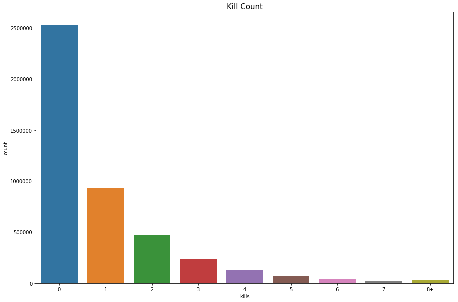

```python
data = train.copy()
data.loc[data['kills'] > data['kills'].quantile(0.99)] = '8+'
plt.figure(figsize=(15,10))
sns.countplot(data['kills'].astype('str').sort_values())
plt.title("Kill Count",fontsize=15)
plt.show()
```

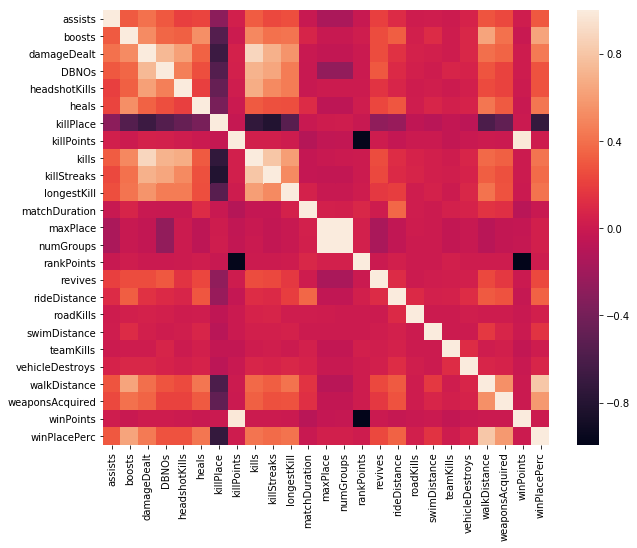

```python
#Identify numerical columns to produce a heatmap, and produce heat map
import seaborn as sns
numcols = [x for x in train.columns]
plt.figure(figsize = (10,8))
sns.heatmap(data=train[numcols].corr())
plt.show()
plt.gcf().clear()
```

We ave noticed that walkDistance has the highest correation with winpercentage. so lets see its distributions

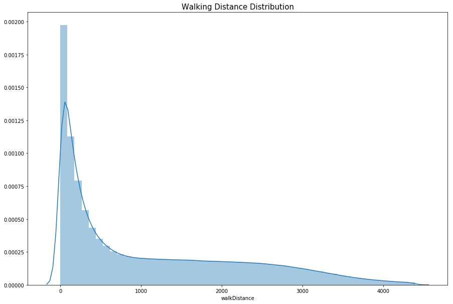

```python
data = train.copy()
data = data[data['walkDistance'] < train['walkDistance'].quantile(0.99)]
plt.figure(figsize=(15,10))
plt.title("Walking Distance Distribution",fontsize=15)
sns.distplot(data['walkDistance'])
plt.show()
```

```python
solos = train[train['numGroups']>50]
duos = train[(train['numGroups']>25) & (train['numGroups']<=50)]
squads = train[train['numGroups']<=25]
print("There are {} ({:.2f}%) solo games, {} ({:.2f}%) duo games and {} ({:.2f}%) squad games.".format(len(solos), 100*len(solos)/len(train), len(duos), 100*len(duos)/len(train), len(squads), 100*len(squads)/len(train),))
```

```
There are 709111 (15.95%) solo games, 3295326 (74.10%) duo games and 442529 (9.95%) squad games.
```

```python
print("{} players ({:.4f}%) have won without a single kill!".format(len(data[data['winPlacePerc']==1]), 100*len(data[data['winPlacePerc']==1])/len(train)))

data1 = train[train['damageDealt'] == 0].copy()
print("{} players ({:.4f}%) have won without dealing damage!".format(len(data1[data1['winPlacePerc']==1]), 100*len(data1[data1['winPlacePerc']==1])/len(train)))
```

```
120407 players (2.7076%) have won without a single kill!
4770 players (0.1073%) have won without dealing damage!
```

```python
print("{} players ({:.4f}%) walked 0 meters. This means that they die before even taking a step or they are afk (more possible).".format(len(data[data['walkDistance'] == 0]), 100*len(data1[data1['walkDistance']==0])/len(train)))
```

```
99603 players (2.0329%) walked 0 meters. This means that they die before even taking a step or they are afk (more possible).
```

Generally what I believe that destroying vehicle and swimming are skill full task and the players who do this a lot are skillful and have a lot of experience in this game. So, they have a good chance to win and there winning percentage should be higher. So let's see how their distributions are.

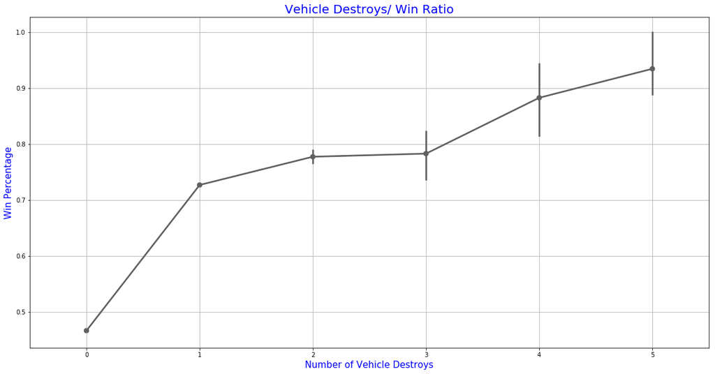

```python
f,ax1 = plt.subplots(figsize =(20,10))
sns.pointplot(x='vehicleDestroys',y='winPlacePerc',data=data,color='#606060',alpha=0.8)
plt.xlabel('Number of Vehicle Destroys',fontsize = 15,color='blue')
plt.ylabel('Win Percentage',fontsize = 15,color='blue')
plt.title('Vehicle Destroys/ Win Ratio',fontsize = 20,color='blue')
plt.grid()
plt.show()
```

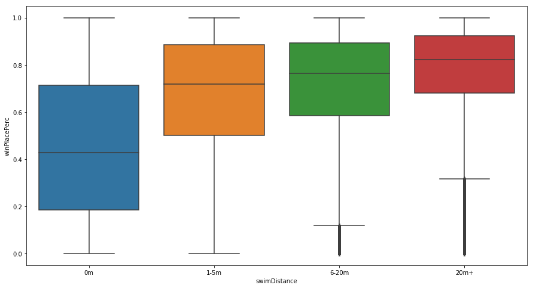

```python
swim = train.copy()
swim['swimDistance'] = pd.cut(swim['swimDistance'], [-1, 0, 5, 20, 5286], labels=['0m','1-5m', '6-20m', '20m+'])
plt.figure(figsize=(15,8))
sns.boxplot(x="swimDistance", y="winPlacePerc", data=swim)
plt.show()
```

So we can note that, as we predicted ... more the Swim Distance and Vehicle destroyed .. more the winning percentage.

# Data Preprocessing

```python
# removing rows not having our target variable
train = train[train['winPlacePerc'].notnull()]
```

```python
#Let's confirm we have all the non nan target variable
train[train['winPlacePerc'].isnull()]
```

|  | Id | groupId | matchId | assists | boosts | damageDealt | DBNOs | headshotKills | heals | killPlace | ... | revives | rideDistance | roadKills | swimDistance | teamKills | vehicleDestroys | walkDistance | weaponsAcquired | winPoints | winPlacePerc |
| --- | --- | --- | --- | --- | --- | --- | --- | --- | --- | --- | --- | --- | --- | --- | --- | --- | --- | --- | --- | --- | --- |

0 rows × 29 columns

# Feature Engineering

A player who has 10 kill amoung 100 player is different than 10 kills a player has when playing among 50 people. so we have to normalise all the factors which can be affected by the number of player in a match. Let' s Do some Feature Engineering

```python
train['playersJoined'] = train.groupby('matchId')['matchId'].transform('count')
```

```python
# Let's create normalized features
train['killsNorm'] = train['kills']*((100-train['playersJoined'])/100 + 1)
train['damageDealtNorm'] = train['damageDealt']*((100-train['playersJoined'])/100 + 1)
train['maxPlaceNorm'] = train['maxPlace']*((100-train['playersJoined'])/100 + 1)
train['matchDurationNorm'] = train['matchDuration']*((100-train['playersJoined'])/100 + 1)
```

```python
train['totalDistance'] = train['rideDistance'] + train['walkDistance'] + train['swimDistance']
train['killsWithoutMoving'] = ((train['kills'] > 0) & (train['totalDistance'] == 0))
train.drop(train[train['killsWithoutMoving'] == True].index, inplace=True)
```

We have tried outlier detection taking help from 3 standard deviations rule and some self knowledgeas well

```python
train.drop(train[train['roadKills'] > 10].index, inplace=True)
```

```python
train.drop(train[train['kills'] > 30].index, inplace=True)
```

```python
train.drop(train[train['longestKill'] >= 1000].index, inplace=True)
```

```python
# Some time people hack the game for auto headshot... this is an outliers we remve them as well using their index
train[(train['headshotKills']/train['kills'] == 1) | (train['kills'] > 10)].head(10)
```

|  | Id | groupId | matchId | assists | boosts | damageDealt | DBNOs | headshotKills | heals | killPlace | ... | weaponsAcquired | winPoints | winPlacePerc | playersJoined | killsNorm | damageDealtNorm | maxPlaceNorm | matchDurationNorm | totalDistance | killsWithoutMoving |
| --- | --- | --- | --- | --- | --- | --- | --- | --- | --- | --- | --- | --- | --- | --- | --- | --- | --- | --- | --- | --- | --- |
| 5 | ff79c12f326506 | 289a6836a88d27 | bac52627a12114 | 0 | 0 | 100.00 | 1 | 1 | 0 | 44 | ... | 1 | 0 | 0.0370 | 95 | 1.05 | 105.0000 | 29.40 | 1464.75 | 34.70 | False |
| 22 | 9b2961d4d51f91 | 799d0a4d61dc3c | e833ca2282169d | 0 | 1 | 192.30 | 1 | 2 | 3 | 15 | ... | 4 | 1494 | 0.7500 | 97 | 2.06 | 198.0690 | 50.47 | 1828.25 | 3596.00 | False |
| 42 | ca3c89d8045645 | 7c0f298b843115 | ecdfcc7fb07cfc | 0 | 0 | 245.60 | 2 | 1 | 0 | 46 | ... | 1 | 0 | 0.0357 | 95 | 1.05 | 257.8800 | 30.45 | 1903.65 | 52.52 | False |
| 59 | d551381427e157 | 39d3a3acbe38d7 | 5a5d23025129e2 | 0 | 2 | 100.00 | 0 | 1 | 2 | 29 | ... | 5 | 0 | 0.6809 | 95 | 1.05 | 105.0000 | 99.75 | 2056.95 | 1606.00 | False |
| 77 | 5d8016d7aa9437 | 9da0fb0be19117 | b4d329043d5c60 | 2 | 1 | 243.10 | 1 | 1 | 1 | 29 | ... | 4 | 0 | 0.7609 | 94 | 1.06 | 257.6860 | 49.82 | 2005.52 | 1749.00 | False |
| 81 | ee3025cc18e7c9 | fabb0207f0c596 | 511978f8a62c1e | 2 | 2 | 129.40 | 1 | 1 | 5 | 23 | ... | 5 | 1621 | 0.9796 | 98 | 1.02 | 131.9880 | 51.00 | 2011.44 | 3563.00 | False |
| 85 | 95aaab951e3eec | 84c97cfeefc4f5 | a1729dc8da7e7a | 0 | 4 | 283.10 | 0 | 1 | 14 | 27 | ... | 3 | 0 | 0.8958 | 97 | 1.03 | 291.5930 | 50.47 | 1830.31 | 3683.00 | False |
| 127 | 3cbab6d3b50b46 | eac94e25fe8e15 | 0a96193a752100 | 0 | 1 | 125.80 | 1 | 1 | 0 | 28 | ... | 2 | 1522 | 0.5625 | 96 | 1.04 | 130.8320 | 50.96 | 1505.92 | 1104.00 | False |
| 130 | 70468fefd77502 | cca2f7d4ac3854 | 95193de7a79656 | 2 | 5 | 396.70 | 0 | 1 | 2 | 26 | ... | 6 | 1575 | 0.8148 | 94 | 1.06 | 420.5020 | 29.68 | 1994.92 | 5899.00 | False |
| 174 | 1615abd7062d41 | 9e888fbff2a36d | 55d89296d27eef | 0 | 2 | 59.16 | 0 | 1 | 1 | 25 | ... | 5 | 0 | 0.8667 | 92 | 1.08 | 63.8928 | 33.48 | 1490.40 | 2507.30 | False |

10 rows × 36 columns

```python
print(train.shape)
```

```
(4445311, 36)
```

```python
train = train[(train['headshotKills']/train['kills'] < 1) | (train['kills'] < 10)]
```

```python
train[['walkDistance', 'rideDistance', 'swimDistance', 'totalDistance','heals','weaponsAcquired']].describe()
```

|  | walkDistance | rideDistance | swimDistance | totalDistance | heals | weaponsAcquired |
| --- | --- | --- | --- | --- | --- | --- |
| count | 4.445287e+06 | 4.445287e+06 | 4.445287e+06 | 4.445287e+06 | 4.445287e+06 | 4.445287e+06 |
| mean | 1.154619e+03 | 6.063215e+02 | 4.510898e+00 | 1.765451e+03 | 1.369857e+00 | 3.655864e+00 |
| std | 1.183508e+03 | 1.498562e+03 | 3.050738e+01 | 2.183248e+03 | 2.679432e+00 | 2.431602e+00 |
| min | 0.000000e+00 | 0.000000e+00 | 0.000000e+00 | 0.000000e+00 | 0.000000e+00 | 0.000000e+00 |
| 25% | 1.554000e+02 | 0.000000e+00 | 0.000000e+00 | 1.584000e+02 | 0.000000e+00 | 2.000000e+00 |
| 50% | 6.863000e+02 | 0.000000e+00 | 0.000000e+00 | 7.892500e+02 | 0.000000e+00 | 3.000000e+00 |
| 75% | 1.977000e+03 | 2.566000e-01 | 0.000000e+00 | 2.729000e+03 | 2.000000e+00 | 5.000000e+00 |
| max | 2.578000e+04 | 4.071000e+04 | 3.823000e+03 | 4.127010e+04 | 8.000000e+01 | 2.360000e+02 |

With the help of the above summary, we can decide where to put the filter for the next 5 columns...

```python
train.drop(train[train['walkDistance'] >= 12500].index, inplace=True)
train.drop(train[train['rideDistance'] >= 20000].index, inplace=True)
train.drop(train[train['swimDistance'] >= 2000].index, inplace=True)
train.drop(train[train['weaponsAcquired'] >= 80].index, inplace=True)
train.drop(train[train['heals'] >= 40].index, inplace=True)
```

```python
train = pd.get_dummies(train, columns=['matchType'])

# Turn groupId and match Id into categorical types
train['groupId'] = train['groupId'].astype('category')
train['matchId'] = train['matchId'].astype('category')

# Get category coding for groupId and matchID
train['groupId_cat'] = train['groupId'].cat.codes
train['matchId_cat'] = train['matchId'].cat.codes
```

```python
# Get rid of old columns
train.drop(['groupId', 'matchId'],axis = 1, inplace=True)

# Lets take a look at our newly created features
train[['groupId_cat', 'matchId_cat']].head()
```

|  | groupId_cat | matchId_cat |
| --- | --- | --- |
| 0 | 613609 | 30085 |
| 1 | 827605 | 32751 |
| 2 | 843298 | 3143 |
| 3 | 1340111 | 45260 |
| 4 | 1757388 | 20531 |

```python
train.drop(['Id'], axis =1, inplace=True)
```

```python
sample = 500000
df_sample = train.sample(sample)
```

```python
df_sample.shape
```

```
(500000, 50)
```

```python
y = df_sample['winPlacePerc']
```

```python
df = df_sample.drop(['winPlacePerc'],axis = 1)
```

```python
df.shape
df = df[['walkDistance','killPlace','totalDistance','boosts','heals','weaponsAcquired','rideDistance','headshotKills',
              'longestKill','damageDealt','revives','playersJoined','rankPoints','numGroups','assists','maxPlaceNorm','DBNOs',
             'kills','damageDealtNorm','swimDistance','matchDuration','killsNorm','killStreaks']].copy()
df.head()
```

|  | walkDistance | killPlace | totalDistance | boosts | heals | weaponsAcquired | rideDistance | headshotKills | longestKill | damageDealt | ... | numGroups | assists | maxPlaceNorm | DBNOs | kills | damageDealtNorm | swimDistance | matchDuration | killsNorm | killStreaks |
| --- | --- | --- | --- | --- | --- | --- | --- | --- | --- | --- | --- | --- | --- | --- | --- | --- | --- | --- | --- | --- | --- |
| 996319 | 1593.0 | 44 | 7307.0 | 2 | 1 | 6 | 5714.0 | 0 | 0.000 | 0.00 | ... | 25 | 0 | 30.80 | 0 | 0 | 0.0000 | 0.0 | 1983 | 0.00 | 0 |
| 2288337 | 1520.0 | 41 | 1520.0 | 0 | 0 | 2 | 0.0 | 0 | 4.069 | 30.73 | ... | 27 | 0 | 29.40 | 1 | 1 | 32.2665 | 0.0 | 1757 | 1.05 | 1 |
| 237473 | 489.5 | 49 | 489.5 | 0 | 0 | 2 | 0.0 | 0 | 0.000 | 168.40 | ... | 47 | 0 | 49.98 | 1 | 0 | 171.7680 | 0.0 | 1399 | 0.00 | 0 |
| 3310979 | 818.8 | 66 | 818.8 | 0 | 0 | 3 | 0.0 | 0 | 0.000 | 0.00 | ... | 28 | 0 | 30.52 | 0 | 0 | 0.0000 | 0.0 | 1297 | 0.00 | 0 |
| 2768533 | 1549.0 | 12 | 2759.0 | 2 | 0 | 4 | 1210.0 | 0 | 17.330 | 321.20 | ... | 27 | 0 | 27.81 | 2 | 3 | 330.8360 | 0.0 | 1308 | 3.09 | 1 |

5 rows × 23 columns

```python
# Function for splitting training and validation data
def split_vals(a, n : int):
    return a[:n].copy(), a[n:].copy()
val_perc = 0.12 # % to use for validation set
n_valid = int(val_perc * sample)
n_trn = len(df)-n_valid
# Split data
raw_train, raw_valid = split_vals(df_sample, n_trn)
X_train, X_valid = split_vals(df, n_trn)
y_train, y_valid = split_vals(y, n_trn)

print('Sample train shape: ', X_train.shape,
      'Sample target shape: ', y_train.shape,
      'Sample validation shape: ', X_valid.shape)
```

```
Sample train shape:  (440000, 23) Sample target shape:  (440000,) Sample validation shape:  (60000, 23)
```

```python
# Machine Learning
import sklearn
from sklearn import metrics
from scipy.cluster import hierarchy as hc
```

```python
from sklearn.ensemble import RandomForestRegressor
from sklearn.model_selection import RandomizedSearchCV

# Metric used for the PUBG competition (Mean Absolute Error (MAE))
from sklearn.metrics import mean_absolute_error

# Function to print the MAE (Mean Absolute Error) score
# This is the metric used by Kaggle in this competition
def print_score(m : RandomForestRegressor):
    res = ['mae train: ', mean_absolute_error(m.predict(X_train), y_train),
           'mae val: ', mean_absolute_error(m.predict(X_valid), y_valid)]
    if hasattr(m, 'oob_score_'): res.append(m.oob_score_)
    print(res)
```

```python
from sklearn.model_selection import GridSearchCV

# Create the parameter grid based on the results of random search
param_grid = {
    'bootstrap': [True],
    'max_depth': [20, 10, 70],
    'max_features': [.7, 1,.5],
    'min_samples_leaf': [.5],
    'min_samples_split': [.8, .5, .2],
    'n_estimators': [150]
}

# Create a based model
rf = RandomForestRegressor()

# Instantiate the grid search model
grid_search = GridSearchCV(estimator = rf, param_grid = param_grid,
                          cv = 2, n_jobs = 1)
```

```python
grid_search.fit(X_train, y_train)
```

```
GridSearchCV(cv=2, error_score='raise',
       estimator=RandomForestRegressor(bootstrap=True, criterion='mse', max_depth=None,
           max_features='auto', max_leaf_nodes=None,
           min_impurity_decrease=0.0, min_impurity_split=None,
           min_samples_leaf=1, min_samples_split=2,
           min_weight_fraction_leaf=0.0, n_estimators=10, n_jobs=1,
           oob_score=False, random_state=None, verbose=0, warm_start=False),
       fit_params=None, iid=True, n_jobs=1,
       param_grid={'bootstrap': [True], 'max_depth': [20, 10, 70], 'max_features': [0.7, 1, 0.5], 'min_samples_leaf': [0.5], 'min_samples_split': [0.8, 0.5, 0.2], 'n_estimators': [150]},
       pre_dispatch='2*n_jobs', refit=True, return_train_score=True,
       scoring=None, verbose=0)
```

```python
def evaluate(model, test_features, test_labels):
    predictions = model.predict(test_features)
    errors = abs(predictions - test_labels)
    mape = 100 * np.mean(errors / test_labels)
    accuracy = 100 - mape
    print('Model Performance')
    print('Average Error: {:0.4f} degrees.'.format(np.mean(errors)))
    print('Accuracy = {:0.2f}%.'.format(accuracy))
    print(print_score(model))

    return accuracy
```

```python
best_grid = grid_search.best_estimator_
best_grid
```

```
RandomForestRegressor(bootstrap=True, criterion='mse', max_depth=20,
           max_features=0.5, max_leaf_nodes=None,
           min_impurity_decrease=0.0, min_impurity_split=None,
           min_samples_leaf=0.5, min_samples_split=0.2,
           min_weight_fraction_leaf=0.0, n_estimators=150, n_jobs=1,
           oob_score=False, random_state=None, verbose=0, warm_start=False)
```

```python
best_grid = grid_search.best_estimator_
grid_accuracy = evaluate(best_grid, X_train, y_train)
```

```
Model Performance
Average Error: 0.2676 degrees.
Accuracy = -inf%.
['mae train: ', 0.26763157852139857, 'mae val: ', 0.2681278227550916]
None
```

```python
# Train basic model
m1 = RandomForestRegressor(n_estimators=150, min_samples_leaf=3, max_features='sqrt', n_jobs=-1)
m1.fit(X_train, y_train)
print_score(m1)
```

```
['mae train: ', 0.038660619671992365, 'mae val: ', 0.060236035359419675]
```

```python
rf_importance = pd.DataFrame(m1.feature_importances_,index = X_train.columns, columns= ['importance']).sort_values('importance',ascending =False)
rf_importance.head(25)
```

|  | importance |
| --- | --- |
| walkDistance | 0.238386 |
| totalDistance | 0.235832 |
| killPlace | 0.201328 |
| boosts | 0.079066 |
| weaponsAcquired | 0.044095 |
| heals | 0.030949 |
| longestKill | 0.023530 |
| rideDistance | 0.023030 |
| damageDealt | 0.017612 |
| matchDuration | 0.017370 |
| killsNorm | 0.012632 |
| damageDealtNorm | 0.012592 |
| numGroups | 0.011994 |
| kills | 0.011741 |
| maxPlaceNorm | 0.010409 |
| playersJoined | 0.009740 |
| rankPoints | 0.004778 |
| killStreaks | 0.004164 |
| DBNOs | 0.003257 |
| assists | 0.003193 |
| swimDistance | 0.002346 |
| headshotKills | 0.001245 |
| revives | 0.000708 |

```python
rf_importance.iloc[1,0]
```

```
0.2358322975352611
```

```python
df_keep = df[['walkDistance','killPlace','totalDistance','boosts','heals','weaponsAcquired','rideDistance','headshotKills',
              'longestKill','damageDealt','revives','playersJoined','rankPoints','numGroups','assists','maxPlaceNorm','DBNOs',
             'kills','damageDealtNorm','swimDistance','matchDuration','killsNorm','killStreaks']].copy()
df_keep.head()
```

|  | walkDistance | killPlace | totalDistance | boosts | heals | weaponsAcquired | rideDistance | headshotKills | longestKill | damageDealt | ... | numGroups | assists | maxPlaceNorm | DBNOs | kills | damageDealtNorm | swimDistance | matchDuration | killsNorm | killStreaks |
| --- | --- | --- | --- | --- | --- | --- | --- | --- | --- | --- | --- | --- | --- | --- | --- | --- | --- | --- | --- | --- | --- |
| 996319 | 1593.0 | 44 | 7307.0 | 2 | 1 | 6 | 5714.0 | 0 | 0.000 | 0.00 | ... | 25 | 0 | 30.80 | 0 | 0 | 0.0000 | 0.0 | 1983 | 0.00 | 0 |
| 2288337 | 1520.0 | 41 | 1520.0 | 0 | 0 | 2 | 0.0 | 0 | 4.069 | 30.73 | ... | 27 | 0 | 29.40 | 1 | 1 | 32.2665 | 0.0 | 1757 | 1.05 | 1 |
| 237473 | 489.5 | 49 | 489.5 | 0 | 0 | 2 | 0.0 | 0 | 0.000 | 168.40 | ... | 47 | 0 | 49.98 | 1 | 0 | 171.7680 | 0.0 | 1399 | 0.00 | 0 |
| 3310979 | 818.8 | 66 | 818.8 | 0 | 0 | 3 | 0.0 | 0 | 0.000 | 0.00 | ... | 28 | 0 | 30.52 | 0 | 0 | 0.0000 | 0.0 | 1297 | 0.00 | 0 |
| 2768533 | 1549.0 | 12 | 2759.0 | 2 | 0 | 4 | 1210.0 | 0 | 17.330 | 321.20 | ... | 27 | 0 | 27.81 | 2 | 3 | 330.8360 | 0.0 | 1308 | 3.09 | 1 |

5 rows × 23 columns

```python
X_train, X_valid = split_vals(df_keep, n_trn)
```

```python
# Train model on top features
m2 = RandomForestRegressor(n_estimators=150, min_samples_leaf=3, max_features='sqrt',n_jobs=-1)
m2.fit(X_train, y_train)
print_score(m2)
```

```
['mae train: ', 0.03863954769917199, 'mae val: ', 0.060260849582678286]
```

```python
# Prepare data
val_perc_full = 0.12 # % to use for validation set
n_valid_full = int(val_perc_full * len(train))
n_trn_full = len(train)-n_valid_full
y = train['winPlacePerc']
df_full = train.drop(['winPlacePerc'], axis = 1) # all columns except target
 # target variable
df_full = df_full[['walkDistance','killPlace','totalDistance','boosts','heals','weaponsAcquired','rideDistance','headshotKills',
              'longestKill','damageDealt','revives','playersJoined','rankPoints','numGroups','assists','maxPlaceNorm','DBNOs',
             'kills','damageDealtNorm','swimDistance','matchDuration','killsNorm','killStreaks']] # Keep only relevant features
X_train, X_valid = split_vals(df_full, n_trn_full)
y_train, y_valid = split_vals(y, n_trn_full)

print('Sample train shape: ', X_train.shape,
      'Sample target shape: ', y_train.shape,
      'Sample validation shape: ', X_valid.shape)
```

```
Sample train shape:  (3911552, 23) Sample target shape:  (3911552,) Sample validation shape:  (533393, 23)
```

```python
# Train final model
# You should get better results by increasing n_estimators
# and by playing around with the parameters
m3 = RandomForestRegressor(n_estimators = 150, min_samples_leaf = 3, max_features=0.5, n_jobs=-1)
m3.fit(X_train, y_train)
print_score(m3)
```

```
['mae train: ', 0.030768920815843315, 'mae val: ', 0.0556395970618513]
```

```python
# Add engineered features to the test set
test = pd.read_csv('test_V2.csv')
test['totalDistance'] = test['rideDistance'] + test['walkDistance'] + test['swimDistance']
test['playersJoined'] = test.groupby('matchId')['matchId'].transform('count')
test['killsNorm'] = test['kills']*((100-test['playersJoined'])/100 + 1)
test['damageDealtNorm'] = test['damageDealt']*((100-test['playersJoined'])/100 + 1)
test['maxPlaceNorm'] = test['maxPlace']*((100-train['playersJoined'])/100 + 1)
test['matchDurationNorm'] = test['matchDuration']*((100-test['playersJoined'])/100 + 1)
test['healsandboosts'] = test['heals'] + test['boosts']
test['killsWithoutMoving'] = ((test['kills'] > 0) & (test['totalDistance'] == 0))

# Turn groupId and match Id into categorical types
test['groupId'] = test['groupId'].astype('category')
test['matchId'] = test['matchId'].astype('category')

# Get category coding for groupId and matchID
test['groupId_cat'] = test['groupId'].cat.codes
test['matchId_cat'] = test['matchId'].cat.codes
```

```python
# Remove irrelevant features from the test set
test_pred = test[['walkDistance','killPlace','totalDistance','boosts','heals','weaponsAcquired','rideDistance','headshotKills',
              'longestKill','damageDealt','revives','playersJoined','rankPoints','numGroups','assists','maxPlaceNorm','DBNOs',
             'kills','damageDealtNorm','swimDistance','matchDuration','killsNorm','killStreaks']].copy()

# Fill NaN with 0 (temporary)
test_pred.fillna(0, inplace=True)
test_pred.head()
```

|  | walkDistance | killPlace | totalDistance | boosts | heals | weaponsAcquired | rideDistance | headshotKills | longestKill | damageDealt | ... | numGroups | assists | maxPlaceNorm | DBNOs | kills | damageDealtNorm | swimDistance | matchDuration | killsNorm | killStreaks |
| --- | --- | --- | --- | --- | --- | --- | --- | --- | --- | --- | --- | --- | --- | --- | --- | --- | --- | --- | --- | --- | --- |
| 0 | 588.0 | 73 | 588.0 | 0 | 0 | 1 | 0.0 | 0 | 0.00 | 51.46 | ... | 28 | 0 | 29.12 | 0 | 0 | 55.5768 | 0.0 | 1884 | 0.00 | 0 |
| 1 | 2017.0 | 11 | 6686.0 | 4 | 2 | 6 | 4669.0 | 0 | 361.90 | 179.10 | ... | 47 | 0 | 52.32 | 0 | 2 | 186.2640 | 0.0 | 1811 | 2.08 | 1 |
| 2 | 787.8 | 49 | 787.8 | 0 | 4 | 4 | 0.0 | 0 | 0.00 | 23.40 | ... | 27 | 1 | 28.56 | 0 | 0 | 24.8040 | 0.0 | 1793 | 0.00 | 0 |
| 3 | 1812.0 | 54 | 1812.0 | 0 | 0 | 3 | 0.0 | 0 | 0.00 | 65.52 | ... | 44 | 0 | 49.05 | 0 | 0 | 72.7272 | 0.0 | 1834 | 0.00 | 0 |
| 4 | 2963.0 | 7 | 2963.0 | 4 | 1 | 4 | 0.0 | 2 | 60.06 | 330.20 | ... | 27 | 0 | 28.84 | 1 | 3 | 346.7100 | 0.0 | 1326 | 3.15 | 1 |

5 rows × 23 columns

```python
# We WILL USE the final Random Forest model with only important variable to get the predictions
predictions = np.clip(a = m3.predict(test_pred), a_min = 0.0, a_max = 1.0)
pred_df = pd.DataFrame({'Id' : test['Id'], 'winPlacePerc' : predictions})

# Creating submission file
pred_df.to_csv("submission.csv", index=False)
```

### Lets try one more Algorithm.... XGBoost (The Comptitions Winner Algorithm)

```python
# Initialising the XGBoost
import xgboost
xgmodel = xgboost.XGBRegressor(colsample_bytree=0.4,
                 gamma=0,
                 learning_rate=0.06,
                 max_depth = 3,
                 min_child_weight = 5,
                 n_estimators= 200,
                 reg_alpha=0.75,
                 reg_lambda=0.45,
                 subsample=0.5,
                 seed=42)
```

```python
# Fitting the XGBOOST Model
xgb = xgmodel.fit(X_train, y_train)
```

```python
def print_score1(m : xgboost.XGBRegressor):
    res = ['mae train: ', mean_absolute_error(m.predict(X_train), y_train),
           'mae val: ', mean_absolute_error(m.predict(X_valid), y_valid)]
    if hasattr(m, 'oob_score_'): res.append(m.oob_score_)
    print(res)
print_score1(xgb)
```

```
['mae train: ', 0.06893282524448278, 'mae val: ', 0.06906003154632145]
```

```python
# Let's make XGBOOST submission
predictions2 = np.clip(a = xgb.predict(test_pred), a_min = 0.0, a_max = 1.0)
pred_df2 = pd.DataFrame({'Id' : test['Id'], 'winPlacePerc' : predictions2})

# Creating submission file
pred_df2.to_csv("submission_xgb.csv", index=False)
```